# IE360_HW1

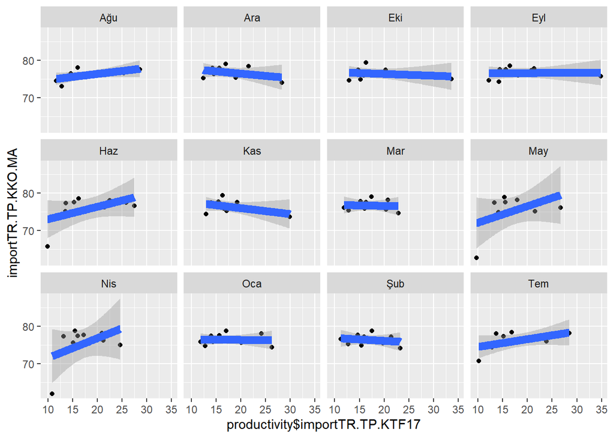

```r
ggplot(productivity,aes(x=productivity$importTR.TP.KTF17,y=importTR.TP.KKO.MA)) +
        geom_point() + geom_smooth(method=lm,linewidth=3) + facet_wrap(~mon)
```

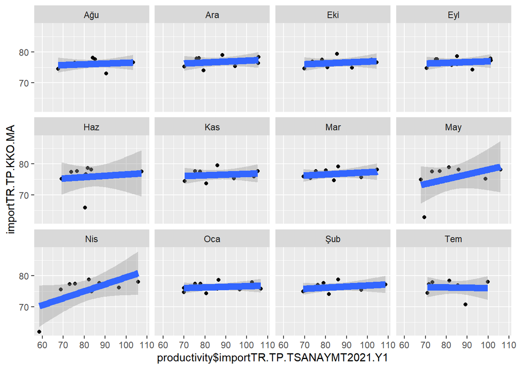

```r
ggplot(productivity,aes(x=productivity$importTR.TP.TSANAYMT2021.Y1,y=importTR.TP.KKO.MA)) +
        geom_point() + geom_smooth(method=lm,linewidth=3) + facet_wrap(~mon)
```

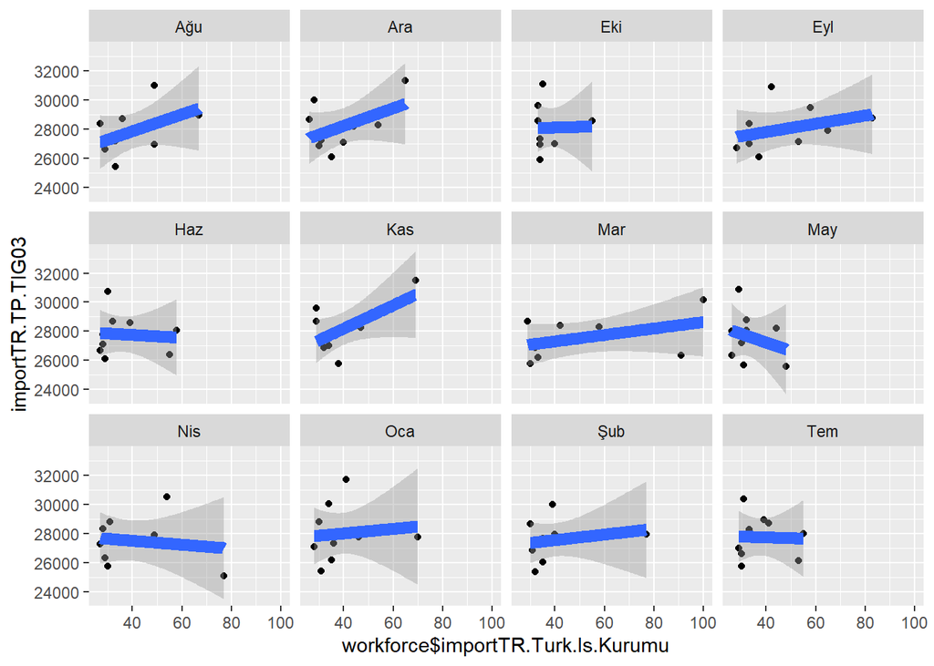

```r
ggplot(workforce,aes(x=workforce$importTR.Turk.Is.Kurumu,y=importTR.TP.TIG03)) +
        geom_point() + geom_smooth(method=lm,linewidth=3) + facet_wrap(~mon)
```

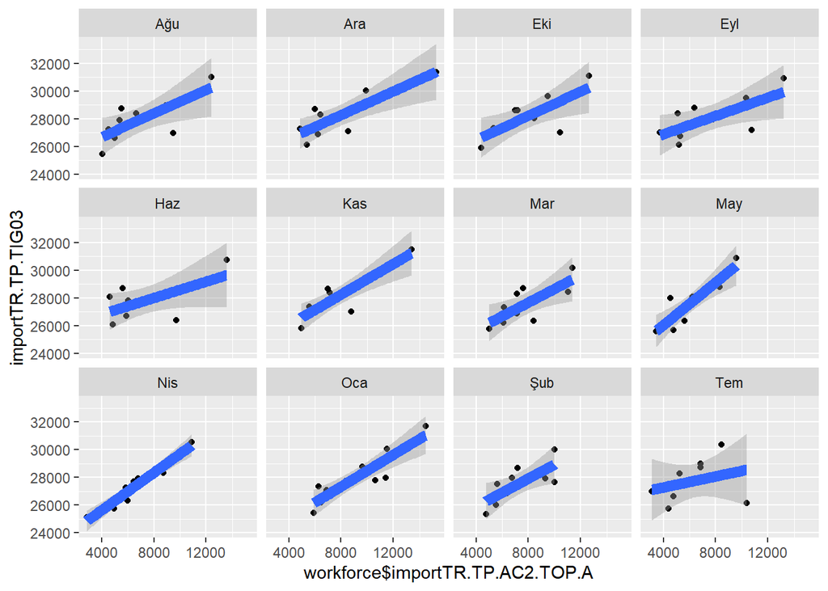

```r
ggplot(workforce,aes(x=workforce$importTR.TP.AC2.TOP.A,y=importTR.TP.TIG03)) +
        geom_point() + geom_smooth(method=lm,linewidth=3) + facet_wrap(~mon)
```

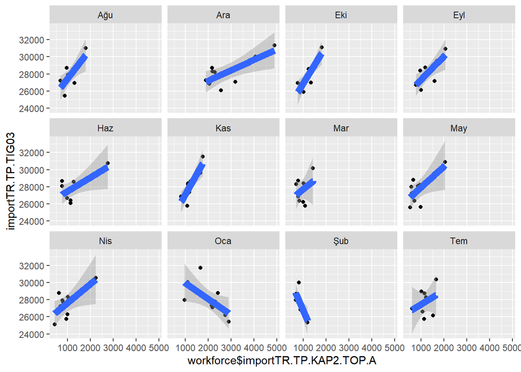

```r
ggplot(workforce,aes(x=workforce$importTR.TP.KAP2.TOP.A,y=importTR.TP.TIG03)) +
        geom_point() + geom_smooth(method=lm,linewidth=3) + facet_wrap(~mon)
```

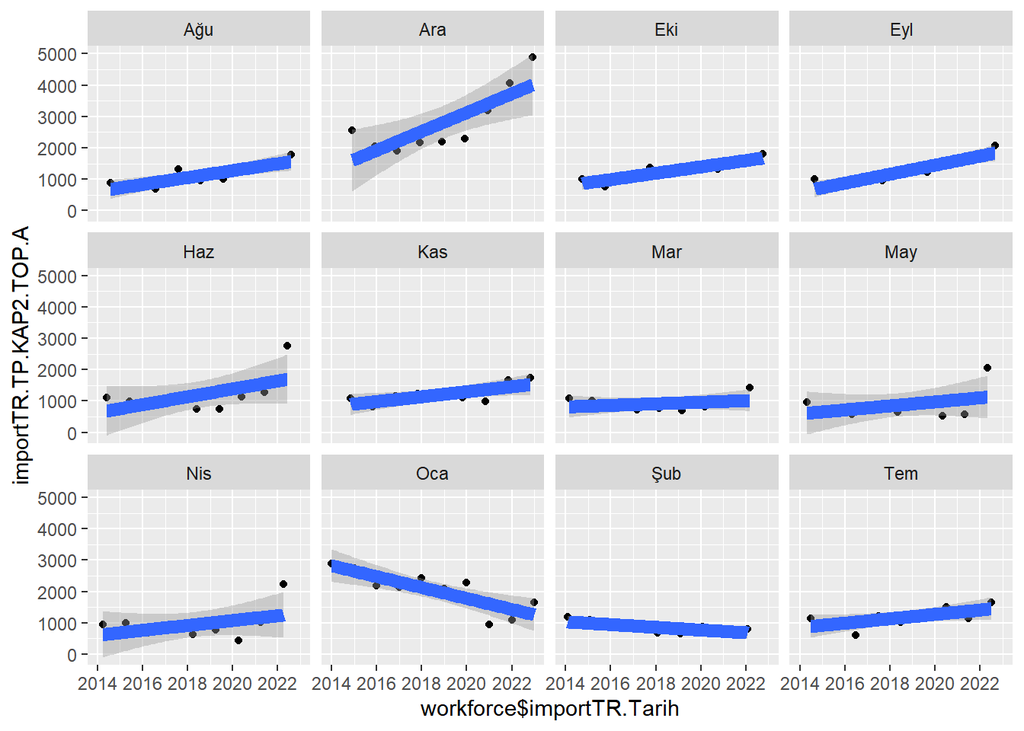

```r
ggplot(workforce,aes(x=workforce$importTR.Tarih,y=importTR.TP.KAP2.TOP.A)) +
        geom_point() + geom_smooth(method=lm,linewidth=3) + facet_wrap(~mon)
```

for our workforce data we may say it has seasonality for some months. For other estimators they have no strong seasonality effect.

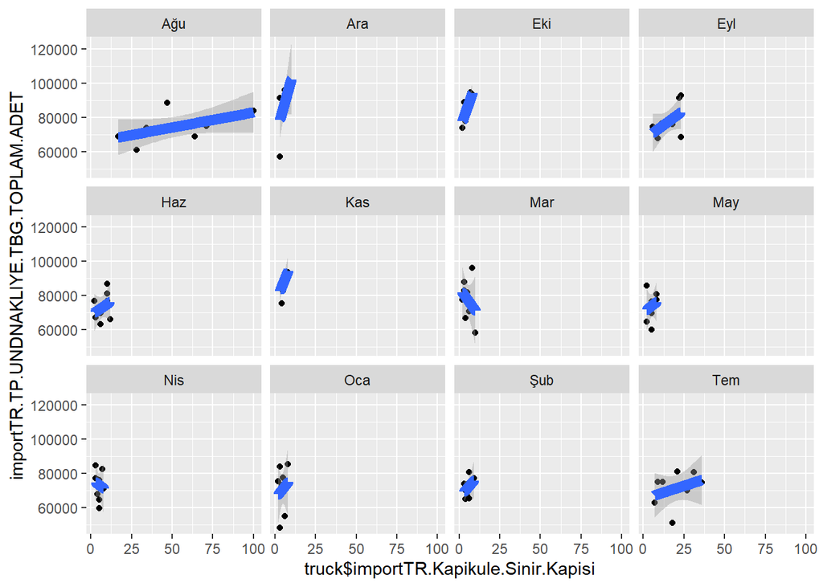

```r
ggplot(truck,aes(x=truck$importTR.Kapikule.Sinir.Kapisi,y=importTR.TP.UNDNAKLIYE.TBG.TOPLAM.ADET)) +
        geom_point() + geom_smooth(method=lm,linewidth=3) + facet_wrap(~mon)
```

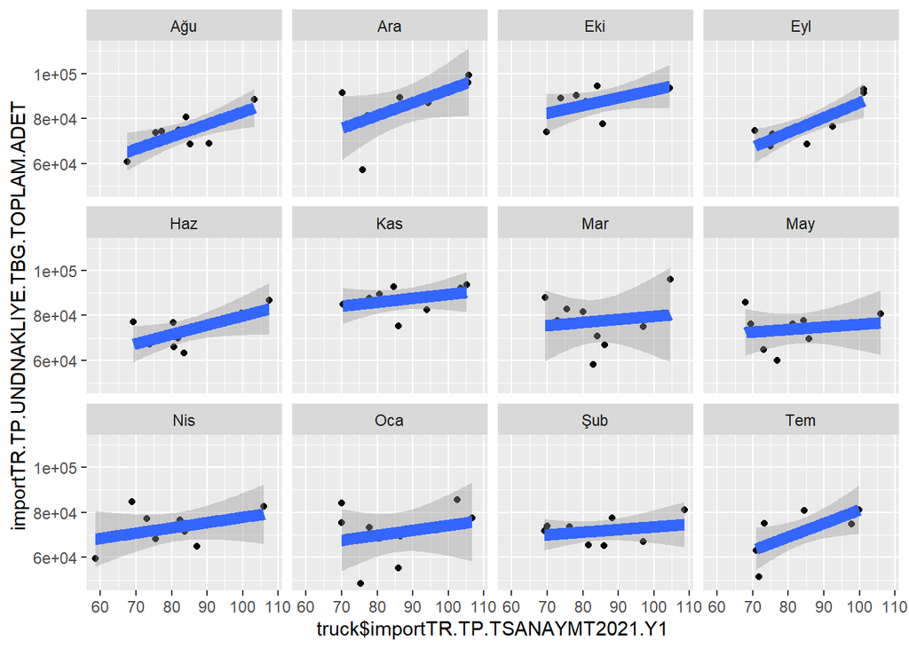

```r
ggplot(truck,aes(x=truck$importTR.TP.TSANAYMT2021.Y1,y=importTR.TP.UNDNAKLIYE.TBG.TOPLAM.ADET)) +
        geom_point() + geom_smooth(method=lm,linewidth=3) + facet_wrap(~mon)
```

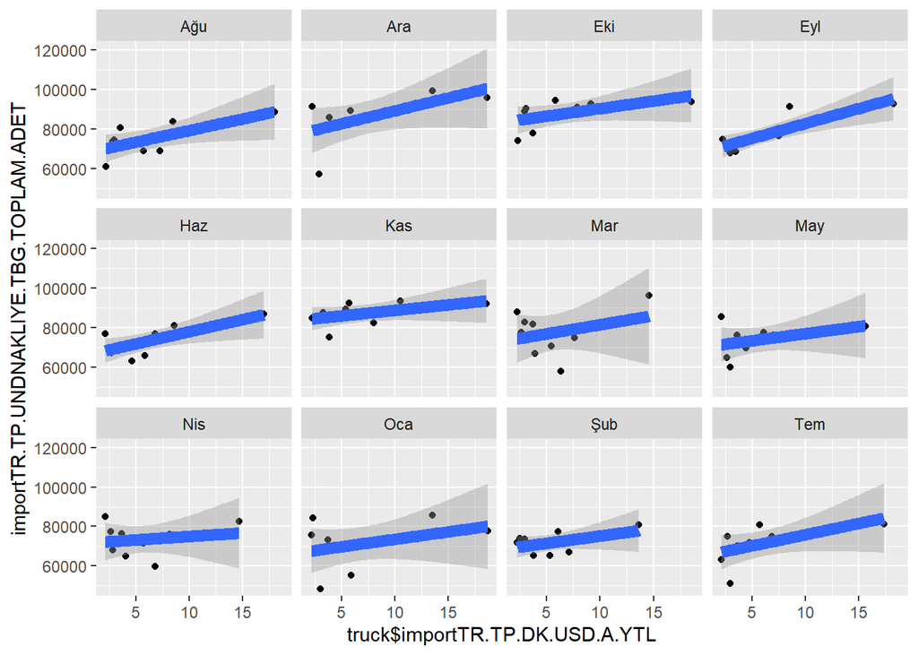

```r
ggplot(truck,aes(x=truck$importTR.TP.DK.USD.A.YTL,y=importTR.TP.UNDNAKLIYE.TBG.TOPLAM.ADET)) +
        geom_point() + geom_smooth(method=lm,linewidth=3) + facet_wrap(~mon)
```

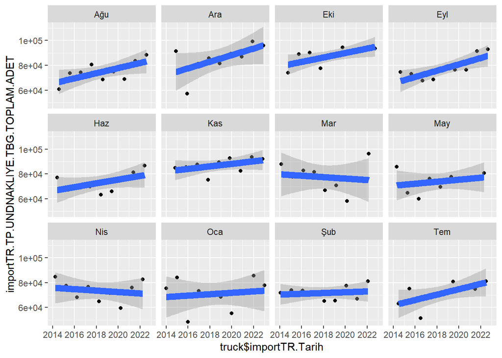

```r
ggplot(truck,aes(x=truck$importTR.Tarih,y=importTR.TP.UNDNAKLIYE.TBG.TOPLAM.ADET)) +
        geom_point() + geom_smooth(method=lm,linewidth=3) + facet_wrap(~mon)
```

For truck we can conclude that significant seasonality exits.

```r
lm_base=lm(importTR.TP.KKO.MA~trnd+mon,productivity)
summary(lm_base)
```

```
##
## Call:
## lm(formula = importTR.TP.KKO.MA ~ trnd + mon, data = productivity)
##
## Residuals:
##      Min       1Q   Median       3Q      Max
## -13.2498  -0.9338   0.6667   1.4913   3.3749
##
## Coefficients:
##              Estimate Std. Error t value Pr(>|t|)
## (Intercept) 76.572772   1.039145  73.688   <2e-16 ***
## trnd        -0.007649   0.008480  -0.902    0.369
## monAra       0.686150   1.307581   0.525    0.601
## monEki       0.359742   1.307251   0.275    0.784
## monEyl       0.496538   1.307168   0.380    0.705
## monHaz      -0.259742   1.307251  -0.199    0.843
## monKas       0.356279   1.307389   0.273    0.786
## monMar       0.550645   1.307828   0.421    0.675
## monMay      -0.700724   1.307389  -0.536    0.593
## monNis      -0.841706   1.307581  -0.644    0.521
## monOca       0.237907   1.274072   0.187    0.852
## monŞub       0.154108   1.308131   0.118    0.906
## monTem       0.081240   1.307168   0.062    0.951
## ---
## Signif. codes:  0 '***' 0.001 '**' 0.01 '*' 0.05 '.' 0.1 ' ' 1
##
## Residual standard error: 2.773 on 96 degrees of freedom
## Multiple R-squared:  0.03648,    Adjusted R-squared:  -0.08396
## F-statistic: 0.3029 on 12 and 96 DF,  p-value: 0.9875
```

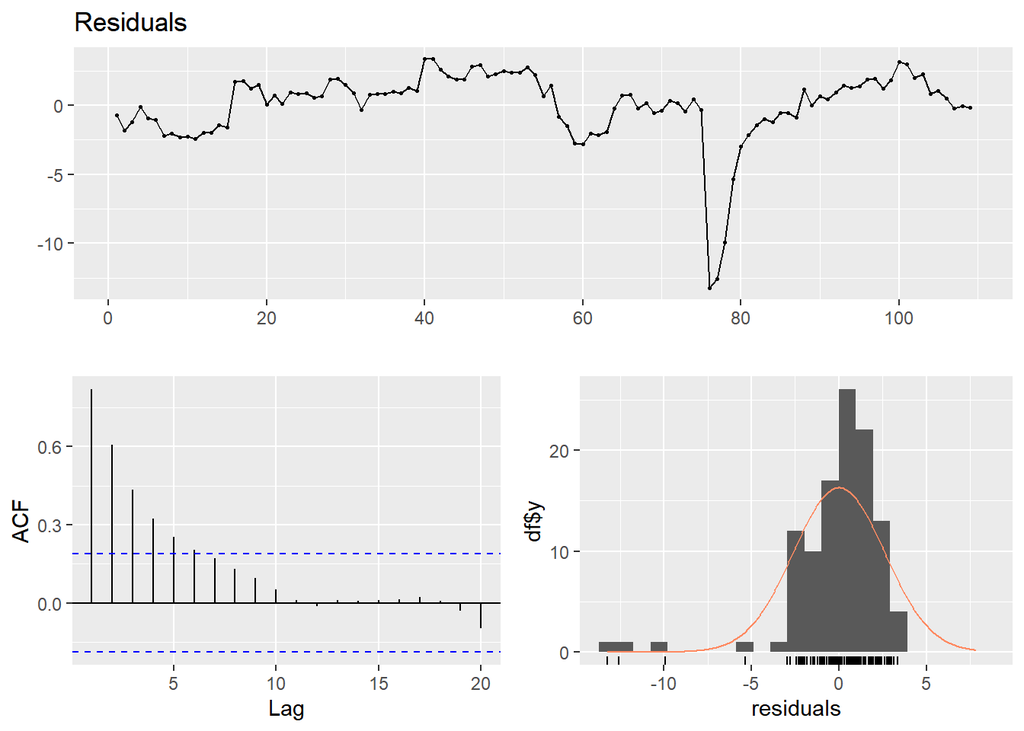

```
##
##  Breusch-Godfrey test for serial correlation of order up to 16
##
## data:  Residuals
## LM test = 75.414, df = 16, p-value = 1.103e-09
```

```r
checkresiduals(lm_base)
```

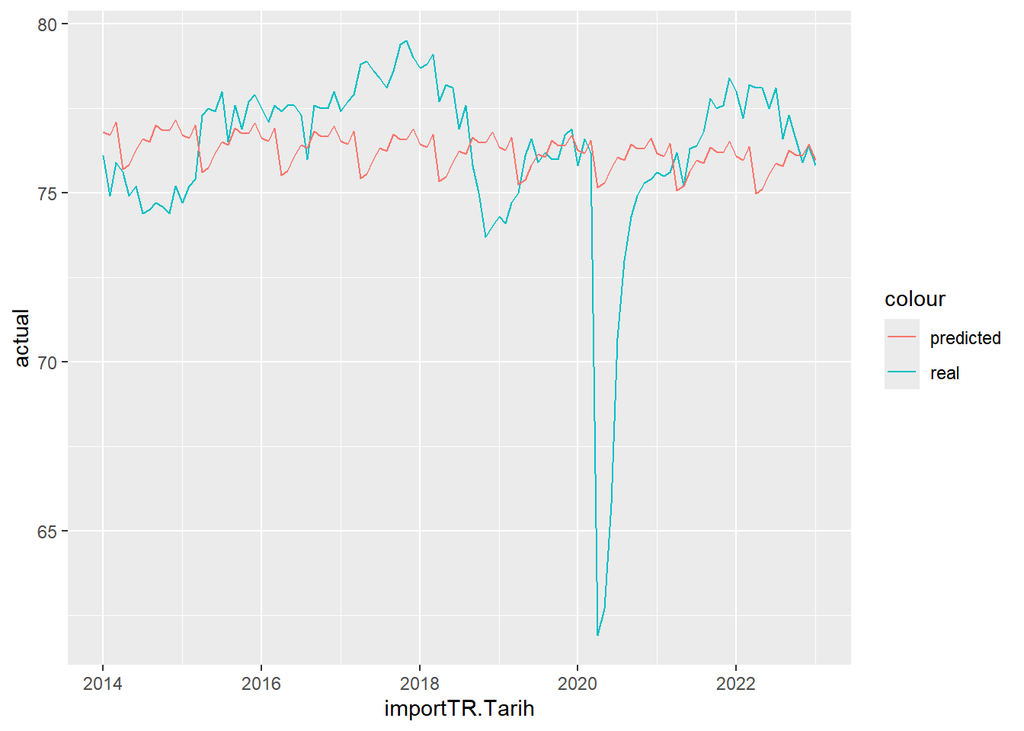

```r
tmp1=copy(productivity)
tmp1[,actual:=importTR.TP.KKO.MA]
tmp1[,predicted_trend:=predict(lm_base,tmp1)]
tmp1[,residual_trend:=actual-predicted_trend]
#head(tmp)
ggplot(tmp1 ,aes(x=importTR.Tarih)) +
        geom_line(aes(y=actual,color='real')) +
        geom_line(aes(y=predicted_trend,color='predicted'))
```

```r
lm_base=lm(importTR.TP.KKO.MA~trnd+mon+importTR.Uretim+importTR.TP.KTF17+importTR.TP.TSANAYMT2021.Y1,productivity)
summary(lm_base)
```

```
##
## Call:
## lm(formula = importTR.TP.KKO.MA ~ trnd + mon + importTR.Uretim +
##     importTR.TP.KTF17 + importTR.TP.TSANAYMT2021.Y1, data = productivity)
##
## Residuals:
##     Min      1Q  Median      3Q     Max
## -2.9956 -1.0730  0.1169  1.0763  2.7303
##
## Coefficients:
##                             Estimate Std. Error t value Pr(>|t|)
## (Intercept)                 54.31955    2.25761  24.061  < 2e-16 ***
## trnd                        -0.11292    0.01241  -9.100 1.64e-14 ***
## monAra                       2.14096    0.80366   2.664  0.00910 **
## monEki                       1.48274    0.76093   1.949  0.05436 .
## monEyl                       0.98334    0.73267   1.342  0.18282
## monHaz                       1.05054    0.75956   1.383  0.16994
## monKas                       1.93522    0.80484   2.404  0.01818 *
## monMar                       2.47062    0.84153   2.936  0.00419 **
## monMay                       1.25684    0.78345   1.604  0.11205
## monNis                       2.13803    0.85062   2.513  0.01367 *
## monOca                       1.54666    0.76821   2.013  0.04697 *
## monŞub                       1.23884    0.78353   1.581  0.11725
## monTem                       0.65360    0.72723   0.899  0.37110
## importTR.Uretim             -0.22532    0.05281  -4.267 4.77e-05 ***
## importTR.TP.KTF17            0.08311    0.03294   2.523  0.01334 *
## importTR.TP.TSANAYMT2021.Y1  0.35957    0.02906  12.375  < 2e-16 ***
## ---
## Signif. codes:  0 '***' 0.001 '**' 0.01 '*' 0.05 '.' 0.1 ' ' 1
##
## Residual standard error: 1.539 on 93 degrees of freedom
## Multiple R-squared:  0.7124, Adjusted R-squared:  0.666
## F-statistic: 15.36 on 15 and 93 DF,  p-value: < 2.2e-16
```

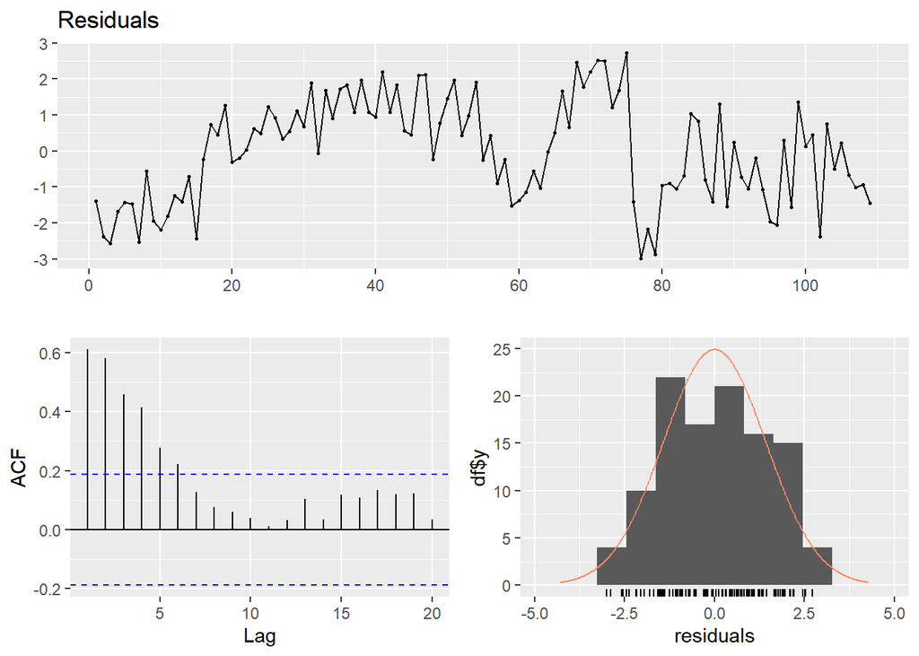

```
##
##  Breusch-Godfrey test for serial correlation of order up to 19
##
## data:  Residuals
## LM test = 55.954, df = 19, p-value = 1.659e-05
```

```r
checkresiduals(lm_base)
```

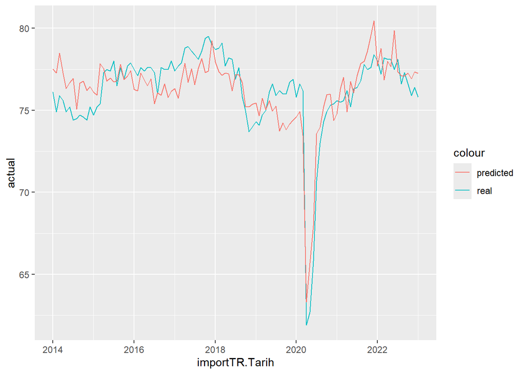

```r
tmp1=copy(productivity)
tmp1[,actual:=importTR.TP.KKO.MA]
tmp1[,predicted_trend:=predict(lm_base,tmp1)]
tmp1[,residual_trend:=actual-predicted_trend]
#head(tmp)
ggplot(tmp1 ,aes(x=importTR.Tarih)) +
        geom_line(aes(y=actual,color='real')) +
        geom_line(aes(y=predicted_trend,color='predicted'))
```

Since productivity reaming belong equibrium as possible as we can use lag 1 differences to construct model for change of productivity

```r
require(zoo)
productivity_lag1dif <- diff(zoo(productivity$importTR.TP.KKO.MA),lag=1,differences = 1,na.pad = TRUE)
productivity$lag_dif <- productivity_lag1dif
productivity <- na.omit(productivity)
productivity$lag_dif <- as.numeric(productivity$lag_dif)
head(productivity)
```

```
##    importTR.Tarih importTR.TP.KKO.MA importTR.Uretim importTR.TP.KTF17
##            <Date>              <num>           <int>             <num>
## 1:     2014-02-01               74.9              19           15.4500
## 2:     2014-03-01               75.9              19           16.0625
## 3:     2014-04-01               75.6              21           15.0625
## 4:     2014-05-01               74.9              19           14.1520
## 5:     2014-06-01               75.2              18           13.5025
## 6:     2014-07-01               74.4              17           12.8625
##    importTR.TP.TSANAYMT2021.Y1  trnd    mon lag_dif
##                          <num> <int> <char>   <num>
## 1:                    69.35886     2    Şub    -1.2
## 2:                    69.44829     3    Mar     1.0
## 3:                    68.84842     4    Nis    -0.3
## 4:                    67.90698     5    May    -0.7
## 5:                    69.28235     6    Haz     0.3
## 6:                    70.97527     7    Tem    -0.8
```

```r
lm_base=lm(productivity$lag_dif~trnd+mon+importTR.Uretim+importTR.TP.KTF17+importTR.TP.TSANAYMT2021.Y1,productivity)
summary(lm_base)
```

```
##
## Call:
## lm(formula = productivity$lag_dif ~ trnd + mon + importTR.Uretim +
##     importTR.TP.KTF17 + importTR.TP.TSANAYMT2021.Y1, data = productivity)
##
## Residuals:
##     Min      1Q  Median      3Q     Max
## -8.9500 -0.5076 -0.1702  0.6092  4.3070
##
## Coefficients:
##                              Estimate Std. Error t value Pr(>|t|)
## (Intercept)                 -10.02339    2.22307  -4.509 1.92e-05 ***
## trnd                         -0.05246    0.01231  -4.260 4.93e-05 ***
## monAra                       -0.26769    0.79063  -0.339   0.7357
## monEki                       -0.41670    0.74852  -0.557   0.5791
## monEyl                        0.44679    0.72068   0.620   0.5368
## monHaz                        0.28063    0.74719   0.376   0.7081
## monKas                       -0.56964    0.79180  -0.719   0.4737
## monMar                       -0.28285    0.82814  -0.342   0.7335
## monMay                       -0.08101    0.77075  -0.105   0.9165
## monNis                       -1.74496    0.83696  -2.085   0.0399 *
## monOca                       -0.82411    0.76961  -1.071   0.2871
## monŞub                       -0.65702    0.77097  -0.852   0.3963
## monTem                        0.52001    0.71531   0.727   0.4691
## importTR.Uretim               0.09080    0.05201   1.746   0.0842 .
## importTR.TP.KTF17            -0.03460    0.03240  -1.068   0.2884
## importTR.TP.TSANAYMT2021.Y1   0.13911    0.02863   4.859 4.83e-06 ***
## ---
## Signif. codes:  0 '***' 0.001 '**' 0.01 '*' 0.05 '.' 0.1 ' ' 1
##
## Residual standard error: 1.514 on 92 degrees of freedom
## Multiple R-squared:  0.2839, Adjusted R-squared:  0.1672
## F-statistic: 2.432 on 15 and 92 DF,  p-value: 0.004995
```

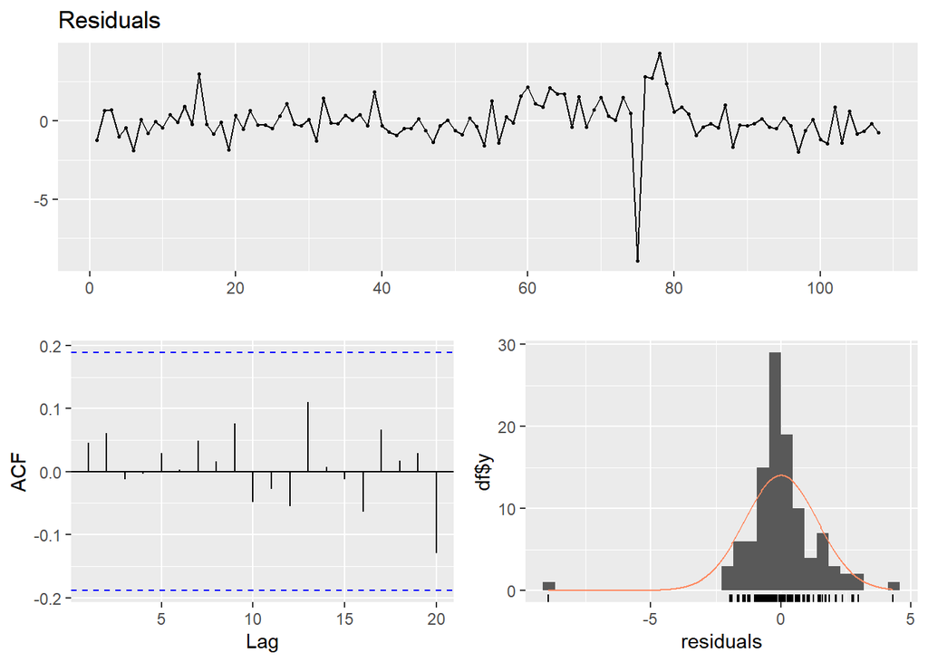

```
##
##  Breusch-Godfrey test for serial correlation of order up to 19
##
## data:  Residuals
## LM test = 5.5327, df = 19, p-value = 0.9988
```

```r
checkresiduals(lm_base)
```

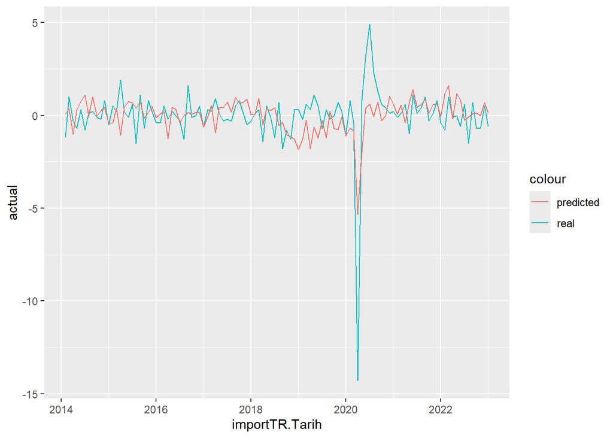

```r
tmp1=copy(productivity)
tmp1[,actual:=lag_dif]
tmp1[,predicted_trend:=predict(lm_base,tmp1)]
tmp1[,residual_trend:=actual-predicted_trend]
#head(tmp)
ggplot(tmp1 ,aes(x=importTR.Tarih)) +
        geom_line(aes(y=actual,color='real')) +
        geom_line(aes(y=predicted_trend,color='predicted'))
```

At lag1 difference model we eliminated autocorelation. However residuals are not normaly distributed. In conclusion R^2 is 0.16 and we failed to construct model

##Model for Workforce Firstly we construct model for trend and seasonality. We can see R^2 is 0.55 so it can be improved by predictor variables

```r
lm_base=lm(importTR.TP.TIG03~trnd+mon,workforce)
summary(lm_base)
```

```
##
## Call:
## lm(formula = importTR.TP.TIG03 ~ trnd + mon, data = workforce)
##
## Residuals:
##     Min      1Q  Median      3Q     Max
## -3296.5  -435.6    79.1   698.0  1724.8
##
## Coefficients:
##              Estimate Std. Error t value Pr(>|t|)
## (Intercept) 25857.189    382.128  67.666   <2e-16 ***
## trnd           36.681      3.118  11.763   <2e-16 ***
## monAra        145.053    480.841   0.302    0.764
## monEki        137.527    480.720   0.286    0.775
## monEyl        106.652    480.689   0.222    0.825
## monHaz        -33.527    480.720  -0.070    0.945
## monKas        141.734    480.770   0.295    0.769
## monMar       -161.594    480.932  -0.336    0.738
## monMay       -157.734    480.770  -0.328    0.744
## monNis       -250.498    480.841  -0.521    0.604
## monOca        129.748    468.519   0.277    0.782
## monŞub       -137.913    481.043  -0.287    0.775
## monTem       -120.763    480.689  -0.251    0.802
## ---
## Signif. codes:  0 '***' 0.001 '**' 0.01 '*' 0.05 '.' 0.1 ' ' 1
##
## Residual standard error: 1020 on 96 degrees of freedom
## Multiple R-squared:  0.6007, Adjusted R-squared:  0.5508
## F-statistic: 12.04 on 12 and 96 DF,  p-value: 1.742e-14
```

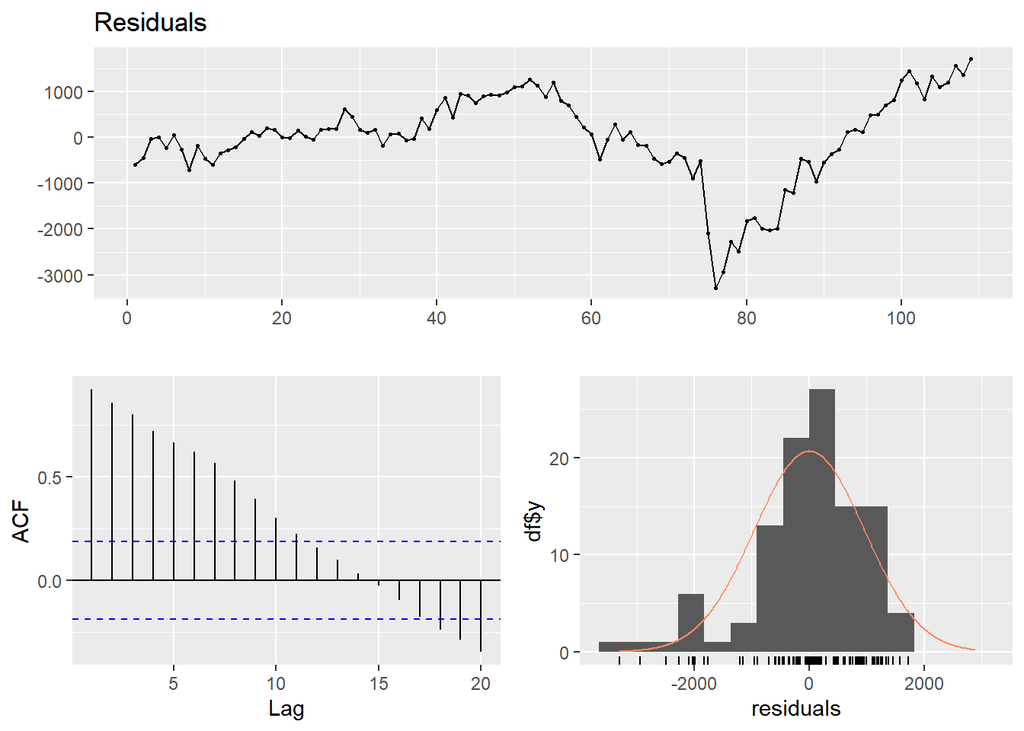

```
##
##  Breusch-Godfrey test for serial correlation of order up to 16
##
## data:  Residuals
## LM test = 98.453, df = 16, p-value = 6.748e-14
```

```r
checkresiduals(lm_base)
```

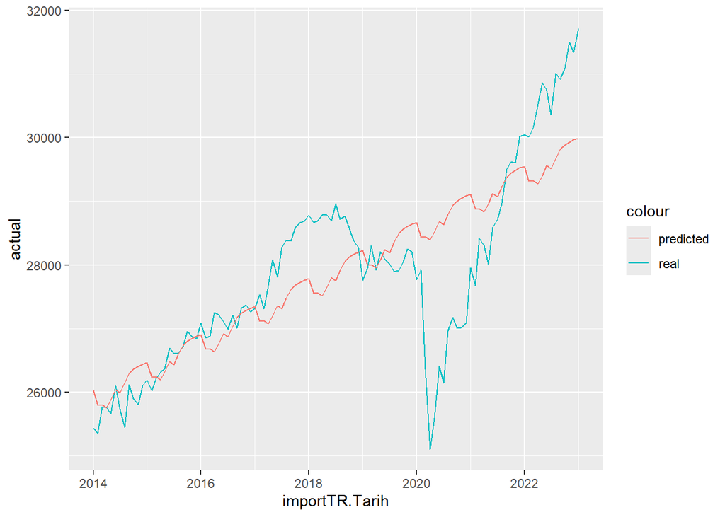

```r
tmp1=copy(workforce)
tmp1[,actual:=importTR.TP.TIG03]
tmp1[,predicted_trend:=predict(lm_base,tmp1)]
tmp1[,residual_trend:=actual-predicted_trend]
#head(tmp)
ggplot(tmp1 ,aes(x=importTR.Tarih)) +
        geom_line(aes(y=actual,color='real')) +
        geom_line(aes(y=predicted_trend,color='predicted'))
```

```r
lm_base=lm(importTR.TP.TIG03~trnd+mon+importTR.Turk.Is.Kurumu+importTR.TP.AC2.TOP.A+importTR.TP.KAP2.TOP.A,workforce)
summary(lm_base)
```

```
##
## Call:
## lm(formula = importTR.TP.TIG03 ~ trnd + mon + importTR.Turk.Is.Kurumu +
##     importTR.TP.AC2.TOP.A + importTR.TP.KAP2.TOP.A, data = workforce)
##
## Residuals:
##      Min       1Q   Median       3Q      Max
## -2757.73  -357.06    66.06   605.52  1583.20
##
## Coefficients:
##                           Estimate Std. Error t value Pr(>|t|)
## (Intercept)              2.567e+04  4.816e+02  53.311  < 2e-16 ***
## trnd                     2.852e+01  5.629e+00   5.066 2.05e-06 ***
## monAra                  -4.038e+02  5.763e+02  -0.701   0.4853
## monEki                  -6.584e+01  4.452e+02  -0.148   0.8827
## monEyl                   1.165e+02  4.480e+02   0.260   0.7955
## monHaz                  -2.137e+02  4.443e+02  -0.481   0.6317
## monKas                  -3.063e+01  4.451e+02  -0.069   0.9453
## monMar                  -1.046e+02  4.690e+02  -0.223   0.8240
## monMay                  -1.297e+02  4.488e+02  -0.289   0.7732
## monNis                  -2.411e+02  4.448e+02  -0.542   0.5892
## monOca                  -4.970e+02  4.742e+02  -1.048   0.2973
## monŞub                  -2.028e+02  4.535e+02  -0.447   0.6558
## monTem                  -1.064e+02  4.449e+02  -0.239   0.8116
## importTR.Turk.Is.Kurumu -1.894e+01  7.493e+00  -2.528   0.0132 *
## importTR.TP.AC2.TOP.A    1.657e-01  7.443e-02   2.226   0.0284 *
## importTR.TP.KAP2.TOP.A   2.367e-01  2.361e-01   1.003   0.3187
## ---
## Signif. codes:  0 '***' 0.001 '**' 0.01 '*' 0.05 '.' 0.1 ' ' 1
##
## Residual standard error: 938.5 on 93 degrees of freedom
## Multiple R-squared:  0.6724, Adjusted R-squared:  0.6195
## F-statistic: 12.72 on 15 and 93 DF,  p-value: < 2.2e-16
```

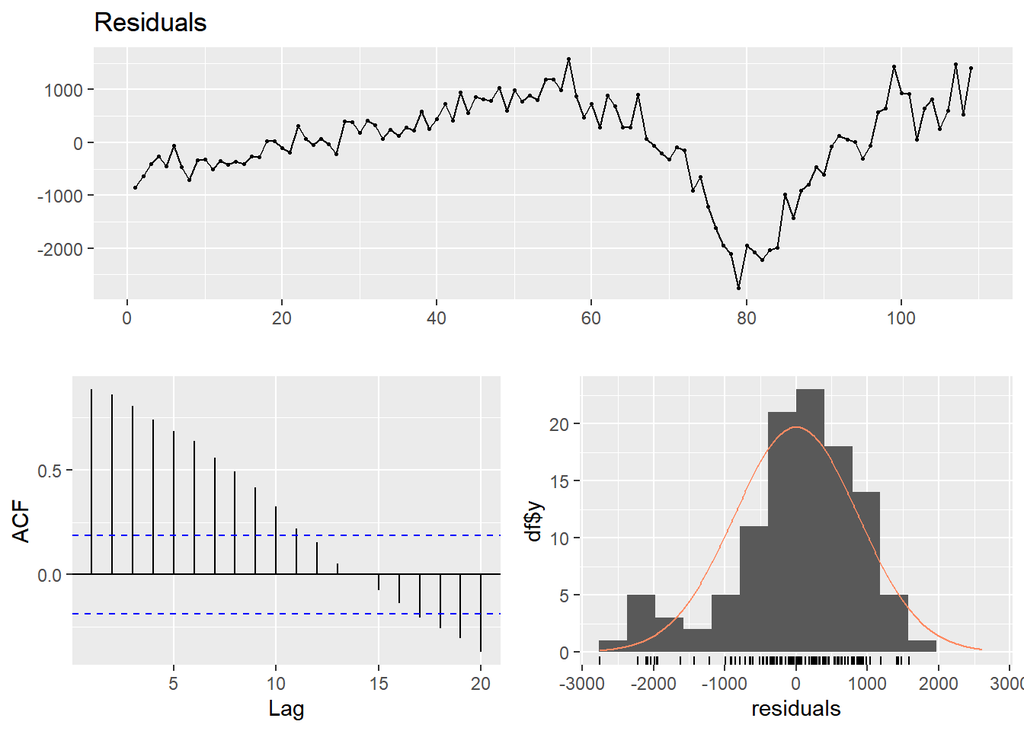

```
##
##  Breusch-Godfrey test for serial correlation of order up to 19
##
## data:  Residuals
## LM test = 98.063, df = 19, p-value = 1.199e-12
```

```r
checkresiduals(lm_base)
```

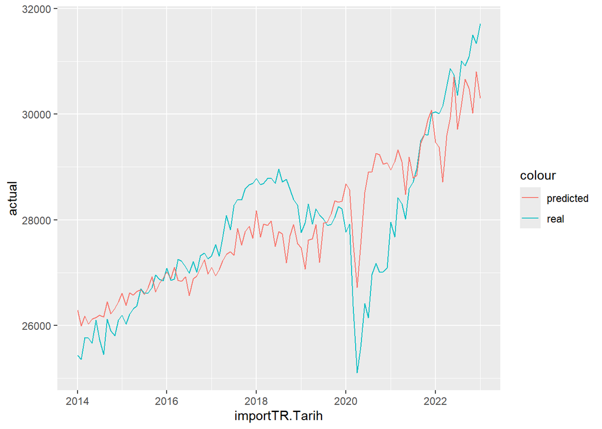

```r
tmp1=copy(workforce)
tmp1[,actual:=importTR.TP.TIG03]
tmp1[,predicted_trend:=predict(lm_base,tmp1)]
tmp1[,residual_trend:=actual-predicted_trend]
#head(tmp)
ggplot(tmp1 ,aes(x=importTR.Tarih)) +
        geom_line(aes(y=actual,color='real')) +
        geom_line(aes(y=predicted_trend,color='predicted'))
```

At the model we have so much autocorelation lags above the limit. Because of that model is unsuccessful.

```r
lm_base=lm(importTR.TP.UNDNAKLIYE.TBG.TOPLAM.ADET~trnd+mon,truck)
summary(lm_base)
```

```
##
## Call:
## lm(formula = importTR.TP.UNDNAKLIYE.TBG.TOPLAM.ADET ~ trnd +
##     mon, data = truck)
##
## Residuals:
##    Min     1Q Median     3Q    Max
## -24756  -3913   1148   4666  17247
##
## Coefficients:
##             Estimate Std. Error t value Pr(>|t|)
## (Intercept) 69493.29    3152.99  22.040  < 2e-16 ***
## trnd           97.56      25.73   3.792 0.000262 ***
## monAra      10076.99    3967.48   2.540 0.012694 *
## monEki      12620.66    3966.47   3.182 0.001972 **
## monEyl       2455.00    3966.22   0.619 0.537398
## monHaz      -1585.11    3966.47  -0.400 0.690320
## monKas      11813.32    3966.89   2.978 0.003673 **
## monMar       2980.79    3968.23   0.751 0.454391
## monMay       -533.21    3966.89  -0.134 0.893355
## monNis      -1054.66    3967.48  -0.266 0.790944
## monOca      -3827.40    3865.80  -0.990 0.324631
## monŞub      -2621.43    3969.14  -0.660 0.510546
## monTem      -3350.77    3966.22  -0.845 0.400308
## ---
## Signif. codes:  0 '***' 0.001 '**' 0.01 '*' 0.05 '.' 0.1 ' ' 1
##
## Residual standard error: 8413 on 96 degrees of freedom
## Multiple R-squared:  0.4162, Adjusted R-squared:  0.3432
## F-statistic: 5.703 on 12 and 96 DF,  p-value: 2.513e-07
```

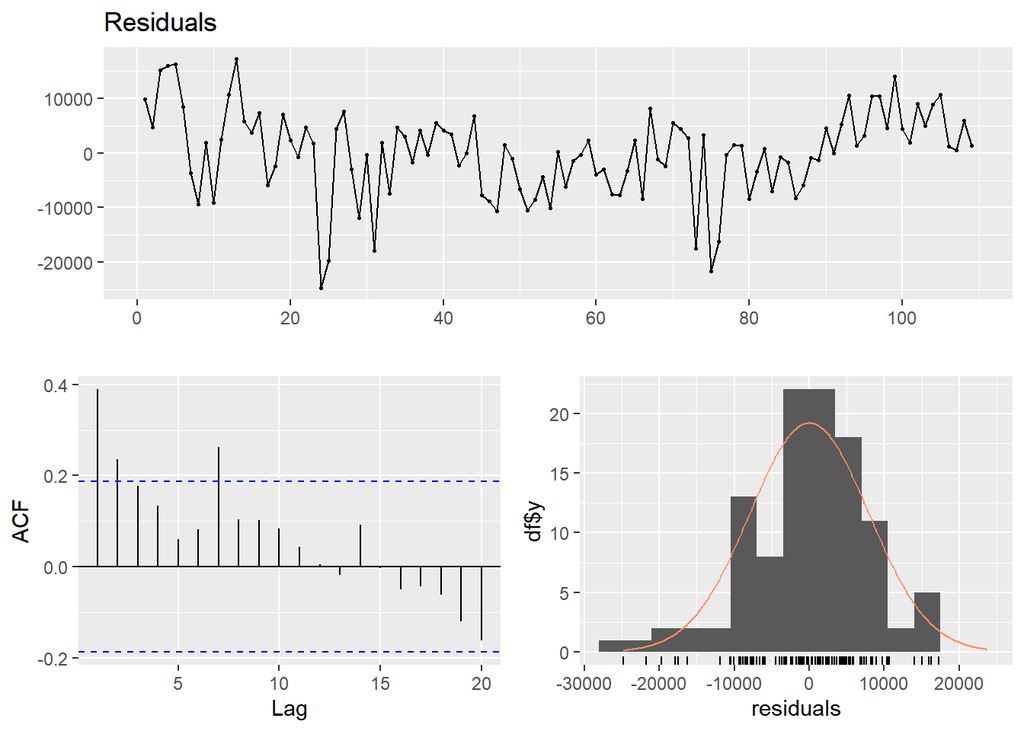

```
##
##  Breusch-Godfrey test for serial correlation of order up to 16
##
## data:  Residuals
## LM test = 26.42, df = 16, p-value = 0.0484
```

```r
checkresiduals(lm_base)
```

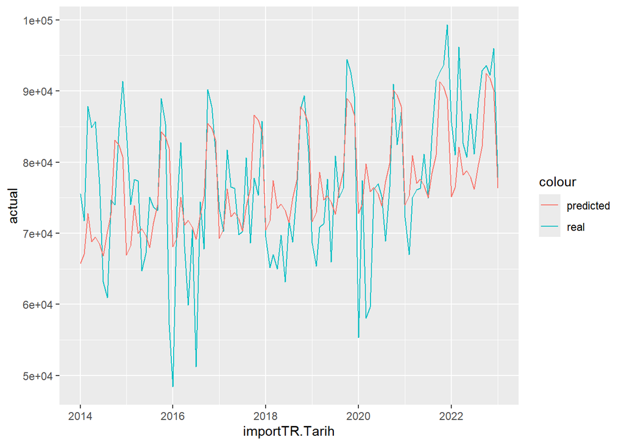

```r
tmp1=copy(truck)
tmp1[,actual:=importTR.TP.UNDNAKLIYE.TBG.TOPLAM.ADET]
tmp1[,predicted_trend:=predict(lm_base,tmp1)]
tmp1[,residual_trend:=actual-predicted_trend]
#head(tmp)
ggplot(tmp1 ,aes(x=importTR.Tarih)) +
        geom_line(aes(y=actual,color='real')) +
        geom_line(aes(y=predicted_trend,color='predicted'))
```

```r
lm_base=lm(importTR.TP.UNDNAKLIYE.TBG.TOPLAM.ADET~trnd+mon+importTR.Kapikule.Sinir.Kapisi+importTR.TP.TSANAYMT2021.Y1+importTR.TP.DK.USD.A.YTL,truck)
summary(lm_base)
```

```
##
## Call:
## lm(formula = importTR.TP.UNDNAKLIYE.TBG.TOPLAM.ADET ~ trnd +
##     mon + importTR.Kapikule.Sinir.Kapisi + importTR.TP.TSANAYMT2021.Y1 +
##     importTR.TP.DK.USD.A.YTL, data = truck)
##
## Residuals:
##      Min       1Q   Median       3Q      Max
## -25571.2  -4275.7    637.1   4224.1  15988.7
##
## Coefficients:
##                                Estimate Std. Error t value Pr(>|t|)
## (Intercept)                    44026.00   10895.27   4.041 0.000110 ***
## trnd                            -162.97      57.82  -2.819 0.005894 **
## monAra                         19631.96    5897.52   3.329 0.001251 **
## monEki                         22490.11    5836.60   3.853 0.000214 ***
## monEyl                         10360.93    5137.89   2.017 0.046624 *
## monHaz                          8211.10    5705.09   1.439 0.153435
## monKas                         21735.96    5906.24   3.680 0.000391 ***
## monMar                         13079.40    5840.67   2.239 0.027516 *
## monMay                          9827.53    5827.61   1.686 0.095076 .
## monNis                          9714.33    5844.59   1.662 0.099859 .
## monOca                          5546.79    5830.45   0.951 0.343893
## monŞub                          7452.32    5861.62   1.271 0.206766
## monTem                          3915.79    4790.15   0.817 0.415752
## importTR.Kapikule.Sinir.Kapisi   201.61      95.18   2.118 0.036828 *
## importTR.TP.TSANAYMT2021.Y1      243.85     148.92   1.637 0.104910
## importTR.TP.DK.USD.A.YTL        1319.87     346.46   3.810 0.000250 ***
## ---
## Signif. codes:  0 '***' 0.001 '**' 0.01 '*' 0.05 '.' 0.1 ' ' 1
##
## Residual standard error: 7507 on 93 degrees of freedom
## Multiple R-squared:  0.5497, Adjusted R-squared:  0.4771
## F-statistic: 7.569 on 15 and 93 DF,  p-value: 1.077e-10
```

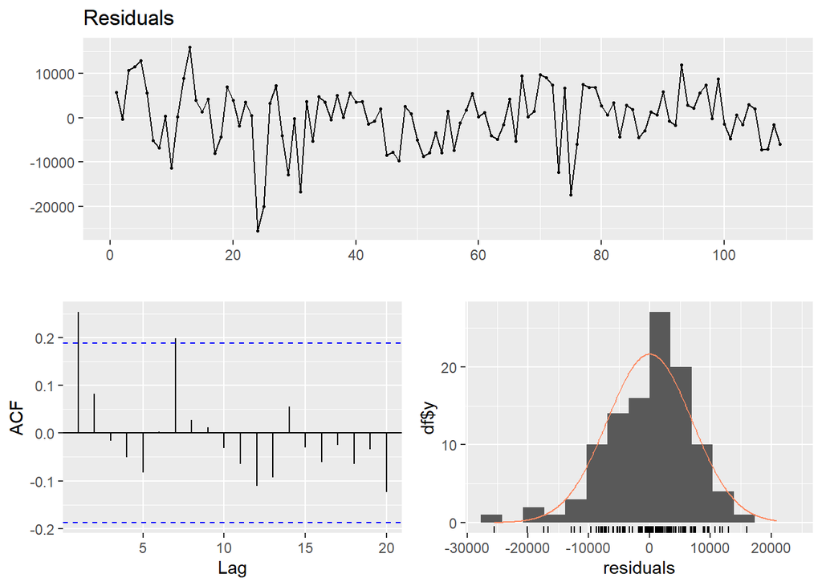

```
##
##  Breusch-Godfrey test for serial correlation of order up to 19
##
## data:  Residuals
## LM test = 15.846, df = 19, p-value = 0.6675
```

```r
checkresiduals(lm_base)
```

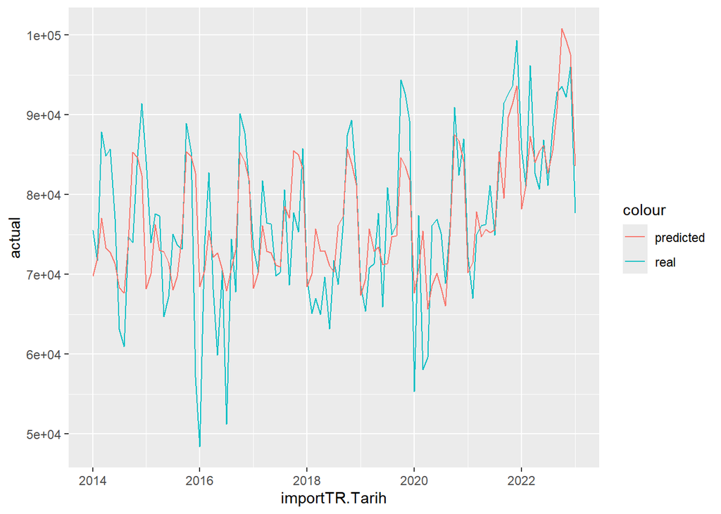

```r
tmp1=copy(truck)
tmp1[,actual:=importTR.TP.UNDNAKLIYE.TBG.TOPLAM.ADET]
tmp1[,predicted_trend:=predict(lm_base,tmp1)]
tmp1[,residual_trend:=actual-predicted_trend]
#head(tmp)
ggplot(tmp1 ,aes(x=importTR.Tarih)) +
        geom_line(aes(y=actual,color='real')) +
        geom_line(aes(y=predicted_trend,color='predicted'))
```

From there we still see lag 1 autocorelation so we can use lag 1 differencing for truck.

```r
truck_lag1dif <- diff(zoo(truck$importTR.TP.UNDNAKLIYE.TBG.TOPLAM.ADET),lag=1,differences = 1,na.pad = TRUE)
truck$lag_dif <- truck_lag1dif
truck <- na.omit(truck)
truck$lag_dif <- as.numeric(truck$lag_dif)
head(truck)
```

```
##    importTR.Tarih importTR.TP.UNDNAKLIYE.TBG.TOPLAM.ADET
##            <Date>                                  <num>
## 1:     2014-02-01                                  71733
## 2:     2014-03-01                                  87857
## 3:     2014-04-01                                  84838
## 4:     2014-05-01                                  85717
## 5:     2014-06-01                                  76983
## 6:     2014-07-01                                  63132
##    importTR.Kapikule.Sinir.Kapisi importTR.TP.TSANAYMT2021.Y1
##                             <int>                       <num>
## 1:                              5                    69.35886
## 2:                              3                    69.44829
## 3:                              3                    68.84842
## 4:                              2                    67.90698
## 5:                              2                    69.28235
## 6:                              7                    70.97527
##    importTR.TP.DK.USD.A.YTL  trnd    mon lag_dif
##                       <num> <int> <char>   <num>
## 1:                 2.212760     2    Şub   -3799
## 2:                 2.217795     3    Mar   16124
## 3:                 2.127471     4    Nis   -3019
## 4:                 2.090805     5    May     879
## 5:                 2.115724     6    Haz   -8734
## 6:                 2.118675     7    Tem  -13851
```

```r
lm_base=lm(lag_dif~trnd+mon+importTR.Kapikule.Sinir.Kapisi+importTR.TP.TSANAYMT2021.Y1+importTR.TP.DK.USD.A.YTL,truck)
summary(lm_base)
```

```
##
## Call:
## lm(formula = lag_dif ~ trnd + mon + importTR.Kapikule.Sinir.Kapisi +
##     importTR.TP.TSANAYMT2021.Y1 + importTR.TP.DK.USD.A.YTL, data = truck)
##
## Residuals:
##      Min       1Q   Median       3Q      Max
## -26466.2  -5323.3    337.3   5382.7  23879.8
##
## Coefficients:
##                                  Estimate Std. Error t value Pr(>|t|)
## (Intercept)                      1343.276  13615.624   0.099   0.9216
## trnd                                5.697     73.152   0.078   0.9381
## monAra                            831.947   7375.192   0.113   0.9104
## monEki                          12625.604   7298.995   1.730   0.0870 .
## monEyl                           3772.594   6424.313   0.587   0.5585
## monHaz                           1193.700   7133.844   0.167   0.8675
## monKas                           1770.213   7386.270   0.240   0.8111
## monMar                           8119.524   7303.092   1.112   0.2691
## monMay                           2935.068   7287.115   0.403   0.6880
## monNis                          -1640.182   7308.404  -0.224   0.8229
## monOca                         -12420.549   7394.390  -1.680   0.0964 .
## monŞub                           3938.344   7329.200   0.537   0.5923
## monTem                          -1101.756   5988.970  -0.184   0.8544
## importTR.Kapikule.Sinir.Kapisi    119.683    119.070   1.005   0.3175
## importTR.TP.TSANAYMT2021.Y1       -61.343    186.111  -0.330   0.7424
## importTR.TP.DK.USD.A.YTL           82.388    434.935   0.189   0.8502
## ---
## Signif. codes:  0 '***' 0.001 '**' 0.01 '*' 0.05 '.' 0.1 ' ' 1
##
## Residual standard error: 9381 on 92 degrees of freedom
## Multiple R-squared:  0.315,  Adjusted R-squared:  0.2034
## F-statistic: 2.821 on 15 and 92 DF,  p-value: 0.0012
```

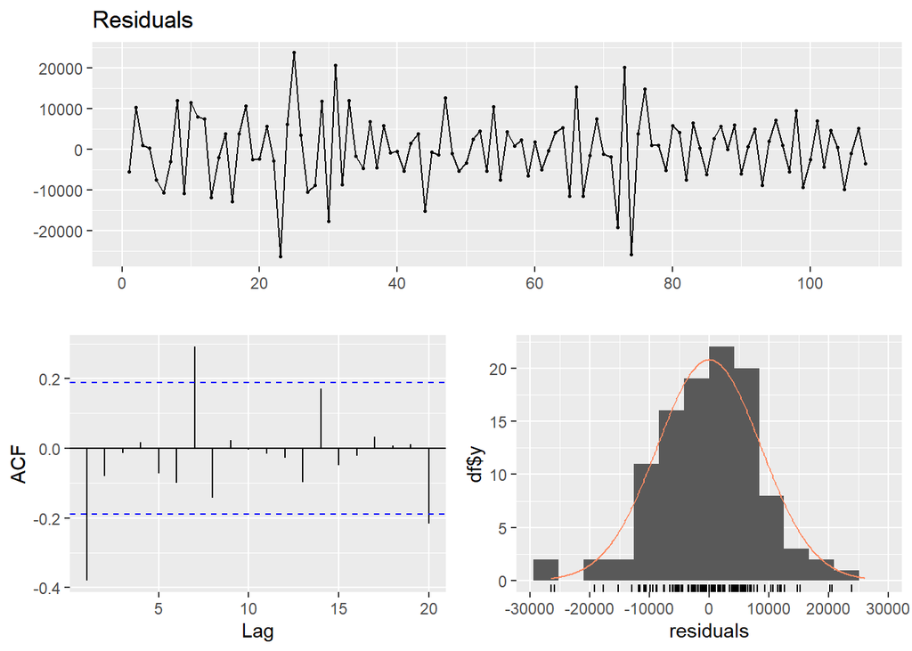

```
##
##  Breusch-Godfrey test for serial correlation of order up to 19
##
## data:  Residuals
## LM test = 43.936, df = 19, p-value = 0.000964
```

```r
checkresiduals(lm_base)
```

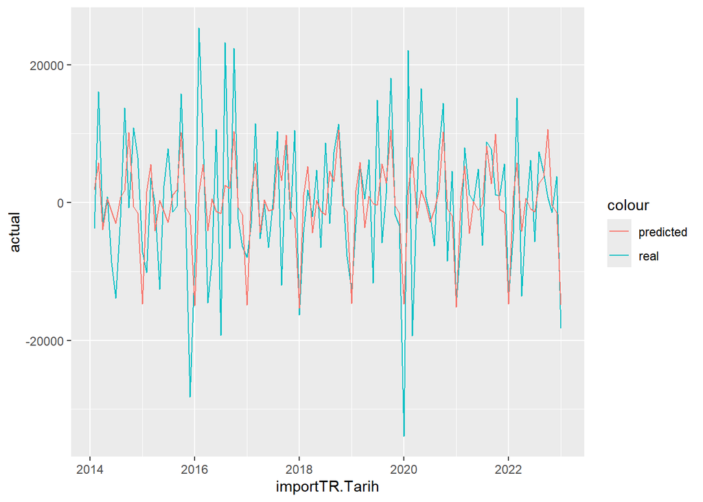

```r
tmp1=copy(truck)
tmp1[,actual:=lag_dif]
tmp1[,predicted_trend:=predict(lm_base,tmp1)]
tmp1[,residual_trend:=actual-predicted_trend]
#head(tmp)
ggplot(tmp1 ,aes(x=importTR.Tarih)) +
        geom_line(aes(y=actual,color='real')) +
        geom_line(aes(y=predicted_trend,color='predicted'))
```

Lag 1 differencing couldn’t solved the problem so 2. model is the best model for now.